# Technical bias in RNA-seq data from larger compendium

J. Taroni for CCDL

2019

The PCA plot for the larger zebrafish test compendium (`05-pca_test_compendium`) showed a separation between what may be 2 groups of RNA-seq samples in PC1.

Here, we’ll dig into what may underlie the difference between the two clusters. We suspect it may have to do with sample prep; specifically, it may be the selection strategy (poly-A enrichment vs. rRNA depletion). First, we need to identify a random selection of samples that we will then read the experimental methods for.

## Set up

```r
`%>%` <- dplyr::`%>%`
library(ggplot2)
```

### Custom Functions

```r
refinebio_sample_code_to_list <- function(accession_code) {
  # given a sample accession code, get the refine.bio sample information at
  # at the samples endpoint into list format with jsonlite::fromJSON
  #
  # Args:
  #   accession_code: sample accession code
  #
  # Returns:
  #   sample endpoint info as a list (from jsonlite::fromJSON)
  api_url <- paste0("https://api.refine.bio/samples/?accession_code=",
                    accession_code)
  sample_info <- jsonlite::fromJSON(api_url)
}
```

```r
get_sample_project_accession <- function(accession_code) {
  # takes the output of refinebio_sample_code_to_list and returns a project
  # (e.g., SRPXXXXXX) for an RNA-seq sample
  #
  # Args:
  #   accession_code: sample accession code (should be RNA-seq!)
  #
  # Returns:
  #   project_accession: the project accession code associated with sample,
  #                      which is extracted from the European Nucleotide
  #                      Archive reference URL

  sample_info <- refinebio_sample_code_to_list(accession_code)

  # this is only intended to work for RNA-seq samples
  if (sample_info$results$technology != "RNA-SEQ")
    stop("get_sample_project_accession only works with RNA-seq samples!")

  # what project accession number did this come from? we can get this from the
  # url of the source reference stored in refine.bio
  reference_url <- sample_info$results$protocol_info[[1]]$Reference
  if (!is.null(reference_url)) {
    project_accession <- stringr::word(reference_url, -1, sep = "/")
  } else {
    project_accession <- NA
  }
}
```

```r
extract_sample_metadata <- function(accession_code) {
  # given an RNA-seq sample (run) accession code (e.g., SRRXXXXX), return the
  # following metadata from the refine.bio API as a data.frame that is a
  # single row:
  #   sample accession code, project accession code (e.g.), library layout,
  #   percent of reads mapped by salmon quant, number of reads, inferred library
  #   type, compatible fragment ratio, which length salmon index was used
  #
  # Args:
  #   accession_code: the sample (run in SRA parlance) accession code
  #                   for an RNA-seq sample such as "SRR998890" (character)
  #
  # Returns:
  #   a data.frame of dimensions 1, 9 that contains the information for the
  #   sample outlined above
  #

  # internal helper function -- there are a bunch of variables that we need
  # to pull from a data.frame and get rid of multiple NAs so we'll use
  # rlang::sym to help us with that
  extract_var_na_rm <- function(var_name = "percent_mapped") {
    sample_info_df %>%
      dplyr::filter(!is.na(!!rlang::sym(var_name))) %>%
      dplyr::pull(!!rlang::sym(var_name))
  }

  # get the sample annotations, etc. from the refine.bio API
  sample_info <- refinebio_sample_code_to_list(accession_code)

  # this is only intended to work for RNA-seq samples
  if (sample_info$results$technology != "RNA-SEQ")
    stop("extract_sample_metadata only works with RNA-seq samples!")

  # what's the SRP|ERP|DRP ? this will help us track down
  project_accession <- get_sample_project_accession(accession_code)

  # the sample annotations contain all the relevant information about the salmon
  # run
  sample_annotations <- sample_info$results$results[[1]]$annotations

  # there are a bunch of empty data.frame -- we don't want that! so let's find
  # the index of what we want and extract it
  nonempty_index <- which(unlist(lapply(lapply(sample_annotations, colnames),
                                        length)) != 0)
  # if there's more than one nonempty data.frame, pick the first one
  # this is a hack but will do for this purpose
  sample_info_df <- sample_annotations[[nonempty_index[1]]]$data

  # paired or single end read -- only paired end will have corrections for
  # GC bias
  gc_bias <- any(sample_info_df$gc_bias_correct)
  if (gc_bias & !is.na(gc_bias)) {
    library_layout <- "PAIRED"
  } else {
    library_layout <- "SINGLE"
  }

  # the library types inferred by salmon quant
  library_type <- unique(unlist(sample_info_df$library_types))
  # if more than one library type was detected, just report it as multiple
  # this will require extra examination
  if (length(library_type) > 1)
    library_type <- "multiple"
  # what % of the reads for this sample are successfully mapped to the txome
  # index?
  percent_mapped <- extract_var_na_rm("percent_mapped")

  # how many reads does this sample have?
  num_reads <- extract_var_na_rm("num_processed")

  # compatible fragment ratio -- a measure of agreement with the inferred
  # library type
  compatible_fragment_ratio <- extract_var_na_rm("compatible_fragment_ratio")

  # what length index was used? (short or long)
  index_length <- extract_var_na_rm("index_length")

  data.frame(
    accession_code,
    experiment = project_accession,
    library_layout,
    platform = sample_info$results$pretty_platform,
    num_reads,
    percent_mapped,
    library_type,
    compatible_fragment_ratio,
    index_length
  )

}
```

```r
get_metadata_df <- function(accession_codes) {
  # given a vector of sample accession codes, return a data.frame with the
  # information returned by extract_sample_metadata; we bind all the rows
  # together
  #
  # Args:
  #   accession_codes: a vector of sample accession codes (should be RNA-seq
  #                    samples) to be used with extract_sample_metadata
  #
  # Returns:
  #   metadata_df: the output of extract_sample_metdata (a 1 row data.frame for
  #                each sample) for each sample, now with the rows in a single
  #                data.frame via dplyr::bind_rows
  metadata_list <- lapply(accession_codes, extract_sample_metadata)
  # metadata_list is a list of 1 row data.frames, so there will be
  # length(metadata_list) warnings about coercing to vector
  metadata_df <- suppressWarnings(dplyr::bind_rows(metadata_list))
}
```

### Set seed for reproducibility

```r
set.seed(6345)
```

## Initial investigation of RNA-seq sample groups

Read in the data for PC1 and PC2 from `05-pca_test_compendium` and filter to only the RNA-seq samples.

```r
pc_file <- file.path("results", "larger_compendium_PC1and2.tsv")
seq_df <- readr::read_tsv(pc_file) %>%
  dplyr::filter(compendium_technology_labels != "MICROARRAY")
```

We’re going to somewhat arbitrarily divide samples into two groups on the basis of their values for PC1.

```r
seq_df <- seq_df %>%
  dplyr::mutate(Group = dplyr::case_when(
    PC1 > 0 ~ "positive",
    PC1 < 0 ~ "negative"
  ))
```

How’s this look?

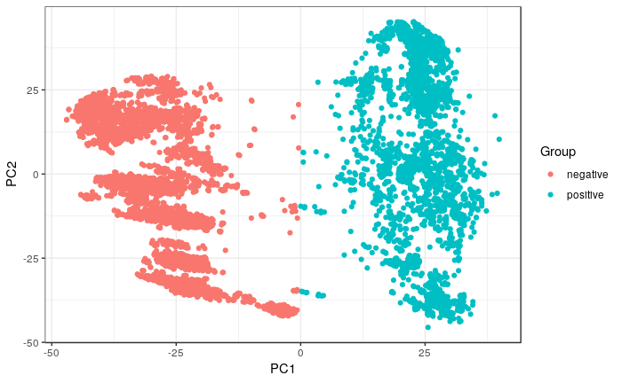

```r
seq_df %>%
  ggplot(aes(x = PC1, y = PC2, colour = Group)) +
  geom_point() +
  theme_bw()
```

This is probably close enough for what we’re after here.

### Random subset of samples from each group

```r
positive_samples <- seq_df %>%
  dplyr::filter(Group == "positive") %>%
  dplyr::pull(Sample) %>%
  sample(50)
```

```r
negative_samples <- seq_df %>%
  dplyr::filter(Group == "negative") %>%
  dplyr::pull(Sample) %>%
  sample(50)
```

We took a look at a handful of samples and couldn’t discern a pattern of poly-A enrichment vs. rRNA depletion. So we decided to dig a bit deeper into metadata from the `salmon quant` runs themselves. (See all the custom functions above.)

### Extract (`salmon quant`) metadata about the two groups

Extract the relevant metadata for the random subset of positive samples

```r
positive_metadata_df <- get_metadata_df(positive_samples)
positive_metadata_df %>%
  dplyr::arrange(experiment)
```

| accession_code | experiment | library_layout | platform | num_reads | percent_mapped | library_type | compatible_fragment_ratio | index_length |
| --- | --- | --- | --- | --- | --- | --- | --- | --- |
| ERR718611 | ERP007082 | PAIRED | IlluminaHiSeq2500 (IlluminaHiSeq2500) | 7324683 | 80.607598 | ISR | 0.9386364 | short |
| ERR1857571 | ERP011556 | PAIRED | IlluminaHiSeq2500 (IlluminaHiSeq2500) | 3070938 | 75.648711 | ISR | 0.9265941 | short |
| ERR1857746 | ERP011556 | PAIRED | IlluminaHiSeq2500 (IlluminaHiSeq2500) | 3128078 | 76.460593 | ISR | 0.9285727 | short |
| ERR1858060 | ERP011556 | PAIRED | IlluminaHiSeq2500 (IlluminaHiSeq2500) | 3003271 | 75.992210 | ISR | 0.9322415 | short |
| ERR1857705 | ERP011556 | PAIRED | IlluminaHiSeq2500 (IlluminaHiSeq2500) | 2975103 | 76.786215 | ISR | 0.9306084 | short |
| ERR1857752 | ERP011556 | PAIRED | IlluminaHiSeq2500 (IlluminaHiSeq2500) | 3143012 | 75.490230 | ISR | 0.9244167 | short |
| ERR1858076 | ERP011556 | PAIRED | IlluminaHiSeq2500 (IlluminaHiSeq2500) | 3168861 | 76.646467 | ISR | 0.9335175 | short |
| ERR1857628 | ERP011556 | PAIRED | IlluminaHiSeq2500 (IlluminaHiSeq2500) | 2924960 | 77.445469 | ISR | 0.9308632 | short |
| ERR1857967 | ERP011556 | PAIRED | IlluminaHiSeq2500 (IlluminaHiSeq2500) | 2653689 | 75.851126 | ISR | 0.9269718 | short |
| ERR1821744 | ERP012128 | PAIRED | IlluminaHiSeq2500 (IlluminaHiSeq2500) | 2322089 | 79.308803 | ISR | 0.9384993 | short |

[output cut: 40 more lines]

Extract the relevant metadata for the random subset of negative samples

```r
negative_metadata_df <- get_metadata_df(negative_samples)
negative_metadata_df %>%
  dplyr::arrange(experiment)
```

| accession_code | experiment | library_layout | platform | num_reads | percent_mapped | library_type | compatible_fragment_ratio | index_length |
| --- | --- | --- | --- | --- | --- | --- | --- | --- |
| ERR525423 | ERP004579 | PAIRED | IlluminaHiSeq2500 (IlluminaHiSeq2500) | 2110687 | 56.17806 | ISR | 0.7192908 | short |
| ERR590774 | ERP005516 | PAIRED | IlluminaHiSeq2500 (IlluminaHiSeq2500) | 4476807 | 63.14382 | ISF | 0.7873167 | short |
| ERR582883 | ERP005517 | PAIRED | IlluminaHiSeq2500 (IlluminaHiSeq2500) | 3099073 | 74.20687 | ISF | 0.6565515 | short |
| ERR582927 | ERP005517 | PAIRED | IlluminaHiSeq2500 (IlluminaHiSeq2500) | 2578939 | 71.65920 | ISF | 0.7202885 | short |
| ERR596712 | ERP005564 | PAIRED | IlluminaHiSeq2500 (IlluminaHiSeq2500) | 1994324 | 60.14394 | ISF | 0.7956130 | short |
| ERR1407584 | ERP006132 | PAIRED | IlluminaHiSeq2500 (IlluminaHiSeq2500) | 1086234 | 72.02159 | ISR | 0.7991878 | short |
| ERR1099493 | ERP006132 | PAIRED | IlluminaHiSeq2500 (IlluminaHiSeq2500) | 1115176 | 50.13433 | ISR | 0.6716766 | short |
| ERR1475719 | ERP006132 | PAIRED | IlluminaHiSeq2500 (IlluminaHiSeq2500) | 1481613 | 61.44223 | ISR | 0.7761826 | short |
| ERR1215540 | ERP006132 | PAIRED | IlluminaHiSeq2500 (IlluminaHiSeq2500) | 1678560 | 32.80419 | ISR | 0.6522761 | short |
| ERR1107969 | ERP006132 | PAIRED | IlluminaHiSeq2500 (IlluminaHiSeq2500) | 2013432 | 40.25773 | ISR | 0.6717327 | short |

[output cut: 40 more lines]

#### Notes on features of two groups

- The positive group contains a mix of library layouts, instruments, and short and long read lengths.
- The negative group is entirely paired-end samples with short read lengths and generally it looks like there are lower % reads mapped. *However* only a few experiments appear to be represented in this group.

### What experiments are represented in the “negative” group?

Do all the negative samples come from very large experiments? Because `ERP008771` and `ERP006132` each have over 2000 samples.

[output not shown]

[output cut: 6 more lines]

## Conclusion

These are all samples from large experiments from the Wellcome Sanger Institute Zebrafish Mutation Project. These samples tend to have fewer reads and lower mapping rates compared to a random selection of samples from the other group.